# Causal Inference - Exercise DAGs

Michael Knaus

SoSe 25

These are the goals of today:

- Find relations, paths, and (conditional) independencies in DAGs

# Getting started

There is a very nice infrastructure around DAGs in R. In particular, we will use the packages `dagitty` that automates the finding of relations, paths and (conditional) independencies, and `ggdag` to nicely display the DAGs.

If you have not installed them, uncomment the first lines in the following code snippet.

```
if (!require("dagitty")) install.packages("dagitty", dependencies = TRUE); library(dagitty)
if (!require("ggdag")) install.packages("ggdag", dependencies = TRUE); library(ggdag)
```

# Redoing chains, forks and colliders

## Chains

### Define the DAG

First, we need to define the DAG representing a chain. To this end, we define a new `dagitty` object that

- defines the variables and their position in a (imaginary) cartesian coordinate system
- the directed edges between the variables

```
# DAG
chain = dagitty('dag{ X [pos = "0,0"]
                      Y [pos = "1,0"]
                      Z [pos = "2,0"]
                      X -> Y
                      Y -> Z}')
```

Use `ggdag` to plot the chain:

```
ggdag(chain) + theme_dag()
```

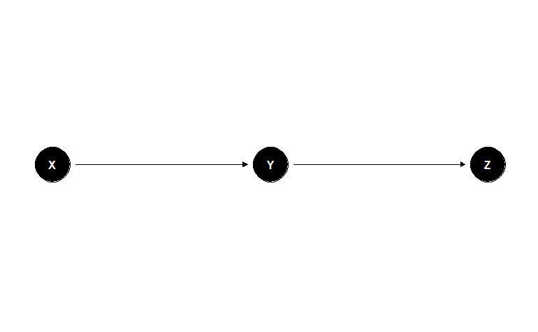

### Find the family

Find the parents of each variable:

```
V = c("X","Y","Z")

for (i in 1:length(V)) {
  cat("Parents of ",V[i],": ", parents(chain,V[i]), "\n")
}
```

```
Parents of  X :
Parents of  Y :  X
Parents of  Z :  Y
```

Find the children of each variable:

```
V = c("X","Y","Z")

for (i in 1:length(V)) {
  cat("Children of ",V[i],": ", children(chain,V[i]), "\n")
}
```

```
Children of  X :  Y
Children of  Y :  Z
Children of  Z :
```

Find the ancestors of each variable:

```
V = c("X","Y","Z")

for (i in 1:length(V)) {
  cat("Ancestors of ",V[i],": ", ancestors(chain,V[i]), "\n")
}
```

```
Ancestors of  X :  X
Ancestors of  Y :  Y X
Ancestors of  Z :  Z Y X
```

Note that every variable is counted as its own ancestor.

Find the descendants of each variable:

```
V = c("X","Y","Z")

for (i in 1:length(V)) {
  cat("Descendants of ",V[i],": ", descendants(chain,V[i]), "\n")
}
```

```
Descendants of  X :  X Y Z
Descendants of  Y :  Y Z
Descendants of  Z :  Z
```

Note that every variable is counted as its own descendant.

### Find the paths between $X$ and $Z$

This is of course trivial but to see that it works:

```
paths(chain,from = "X", to = "Z")
```

```
$paths
[1] "X -> Y -> Z"

$open
[1] TRUE
```

Additionally to the path, we get also the information that the path is “open” unconditionally b/c it is not blocked by anything.

However, we can check whether the path remains open if we condition on $Y$:

```
paths(chain,from = "X", to = "Z", Z = "Y")
```

```
$paths
[1] "X -> Y -> Z"

$open
[1] FALSE
```

Now the path is closed.

### List (conditional) independencies in the DAG

The `impliedConditionalIndependencies()` function displays the independencies (including unconditional ones) that are implied by the graph. This is very useful for larger graphs.

```
impliedConditionalIndependencies(chain,"all.pairs")
```

```
X _||_ Z | Y
```

The `all.pairs` option insists on checking all possible pairs and printing all independencies. In our toy models this is okay but in larger models, we would remove this to get rid of trivial independencies like that we can always condition on variables not on the path that are non-descendants of a collider.

## Do the same for forks

Set up the graph for forks and verify family and independencies.

```
# DAG
fork = dagitty('dag{ X [pos = "1,1"]
                      Y [pos = "0,0"]
                      Z [pos = "2,0"]
                      X -> Y
                      X -> Z}')

ggdag(fork) + theme_dag()
```

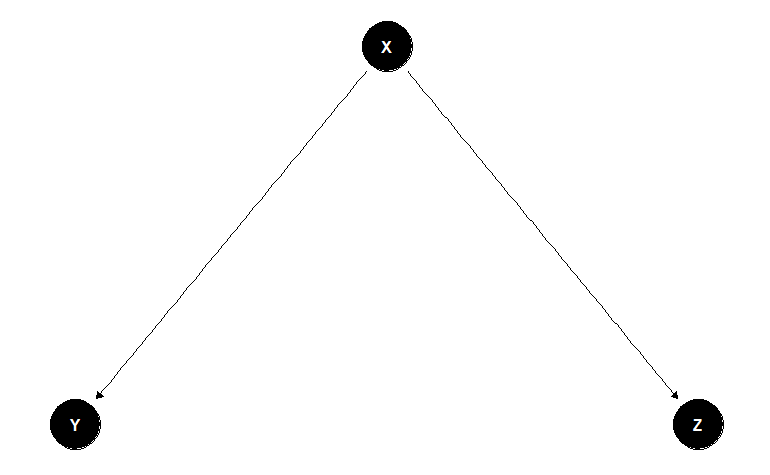

### Find the family

```
V = c("X","Y","Z")

for (i in 1:length(V)) {
  cat("Parents of ",V[i],": ", parents(fork,V[i]), "\n")
}
```

```
Parents of  X :
Parents of  Y :  X
Parents of  Z :  X
```

```
V = c("X","Y","Z")

for (i in 1:length(V)) {
  cat("Children of ",V[i],": ", children(fork,V[i]), "\n")
}
```

```
Children of  X :  Y Z
Children of  Y :
Children of  Z :
```

```
V = c("X","Y","Z")

for (i in 1:length(V)) {
  cat("Ancestors of ",V[i],": ", ancestors(fork,V[i]), "\n")
}
```

```
Ancestors of  X :  X
Ancestors of  Y :  Y X
Ancestors of  Z :  Z X
```

```
V = c("X","Y","Z")

for (i in 1:length(V)) {
  cat("Descendants of ",V[i],": ", descendants(fork,V[i]), "\n")
}
```

```
Descendants of  X :  X Z Y
Descendants of  Y :  Y
Descendants of  Z :  Z
```

Note that every variable is counted as its own descendant.

This is of course trivial but to see that it works:

```
paths(fork,from = "Y", to = "Z")
```

```
$paths
[1] "Y <- X -> Z"

$open
[1] TRUE
```

Additionally to the path, we get also the information that the path is “open” unconditionally b/c it is not blocked by anything.

```
paths(fork,from = "Y", to = "Z", Z = "X")
```

```
$paths
[1] "Y <- X -> Z"

$open
[1] FALSE
```

Now the path is closed.

### List (conditional) independencies in the DAG

The `impliedConditionalIndependencies()` function displays the independencies (including unconditional ones) that are implied by the graph. This is very useful for larger graphs.

```
impliedConditionalIndependencies(fork,"all.pairs")
```

```
Y _||_ Z | X
```

## Colliders

Now we do everything for colliders:

```
# DAG
collider = dagitty('dag{ X [pos = "0,1"]
                      Y [pos = "2,1"]
                      Z [pos = "1,0"]
                      X -> Z
                      Y -> Z}')
ggdag(collider) + theme_dag()
```

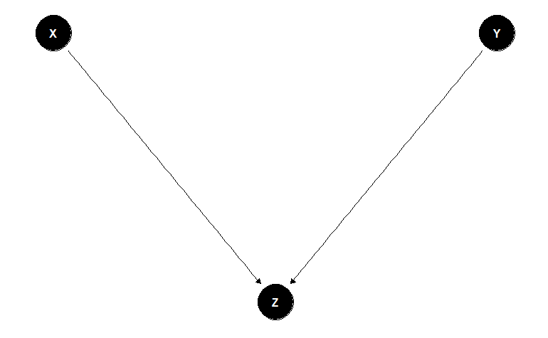

### Find the family

Find the parents of each variable:

```
V = c("X","Y","Z")

for (i in 1:length(V)) {
  cat("Parents of ",V[i],": ", parents(collider,V[i]), "\n")
}
```

```
Parents of  X :
Parents of  Y :
Parents of  Z :  X Y
```

Find the children of each variable:

```
V = c("X","Y","Z")

for (i in 1:length(V)) {
  cat("Children of ",V[i],": ", children(collider,V[i]), "\n")
}
```

```
Children of  X :  Z
Children of  Y :  Z
Children of  Z :
```

Find the ancestors of each variable:

```
V = c("X","Y","Z")

for (i in 1:length(V)) {
  cat("Ancestors of ",V[i],": ", ancestors(collider,V[i]), "\n")
}
```

```
Ancestors of  X :  X
Ancestors of  Y :  Y
Ancestors of  Z :  Z Y X
```

Find the descendants of each variable:

```
V = c("X","Y","Z")

for (i in 1:length(V)) {
  cat("Descendants of ",V[i],": ", descendants(collider,V[i]), "\n")
}
```

```
Descendants of  X :  X Z
Descendants of  Y :  Y Z
Descendants of  Z :  Z
```

### Find the paths between $X$ and $Y$

This is of course trivial but to see that it works:

```
paths(collider,from = "X", to = "Y")
```

```
$paths
[1] "X -> Z <- Y"

$open
[1] FALSE
```

We get the information that this path is blocked.

Now we can observe how conditioning on the collider unblocks the path:

```
paths(collider, from = "X", to = "Y", Z = "Z")
```

```
$paths
[1] "X -> Z <- Y"

$open
[1] TRUE
```

Now the path is open.

### List (conditional) independencies in the DAG

The program also documents the obvious unconditional independence.

```
impliedConditionalIndependencies(collider,"all.pairs")
```

```
X _||_ Y
```

# Graph from the lecture

Computationally verify the (conditional) (in)dependence relations we manually derived in class.

This is the starting DAG:

```
dag_lecture = dagitty('dag{ Z [pos = "0,1"]
                            X [pos = "2,1"]
                            Y [pos = "3,1"]
                            W [pos = "1,0.5"]
                            U [pos = "1,0"]
                            X -> W
                            X -> Y
                            Z -> W
                            W -> U
                      }')

ggdag(dag_lecture) + theme_dag()
```

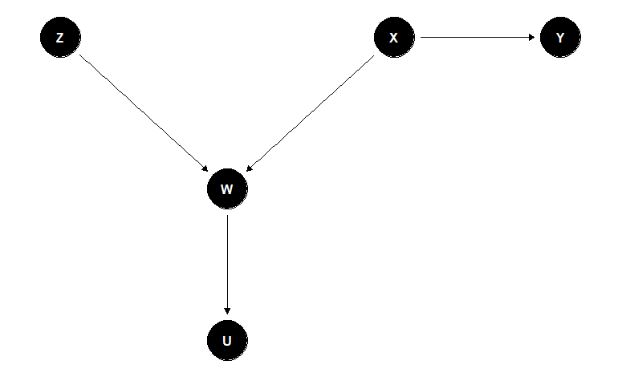

```
# impliedConditionalIndependencies(dag_lecture)
impliedConditionalIndependencies(dag_lecture,"all.pairs")
```

```
U _||_ X | W
U _||_ X | W, Y
U _||_ X | W, Z
U _||_ X | W, Y, Z
U _||_ Y | W
U _||_ Y | X
U _||_ Y | W, X
U _||_ Y | W, Z
U _||_ Y | X, Z
U _||_ Y | W, X, Z
U _||_ Z | W
U _||_ Z | W, X
U _||_ Z | W, Y
U _||_ Z | W, X, Y
W _||_ Y | X
W _||_ Y | U, X
W _||_ Y | X, Z
W _||_ Y | U, X, Z
X _||_ Z
X _||_ Z | Y
Y _||_ Z
Y _||_ Z | X
Y _||_ Z | U, X
Y _||_ Z | W, X
Y _||_ Z | U, W, X
```

# (optional self-study) Use any other DAG

Create any new DAG or expand one of those above. One idea would be to browse [Pearls book](https://ebookcentral.proquest.com/lib/unitueb/detail.action?docID=4383483) for inspiration. In the best case do it manually first and use the computer to verify your results.